# FIFA World Cup Match Attendance Analysis (1930-2014)

Yousaf Jan (100865968)

### Exploring the trends in Soccer

## Why This Dataset?

I analyzed FIFA World Cup match data from 1930 to 2014, covering match dates, teams, goals, attendance, and key event details. As a fan of soccer for my whole life, I wanted to explore how the World Cup has evolved, especially in match attendance and global interest.

The data was sourced from Kaggle: https://www.kaggle.com/datasets/abecklas/fifa-world-cup

This analysis addresses:

1. How has attendance changed over time?
2. Which countries reached the final most often?
3. Which matchups drew the largest crowds?
4. Which teams scored the most goals in the 1958 World Cup, and how did they perform across stages?
5. How does the home team impact attendance?
6. How do goal distributions vary by decade?

## Data Collection

```r
# Load necessary libraries
library(dplyr)
library(ggplot2)
library(sf)
library(rnaturalearth)
library(rnaturalearthdata)
library(tidyr)
library(treemap)
library(scales)

# Read the FIFA World Cup dataset
fifa_data <- read.csv("attendance.csv")
```

## Data Cleaning

```r
# Clean column names by removing periods
colnames(fifa_data) <- gsub("\\.", " ", colnames(fifa_data))

fifa_data_cleaned <- fifa_data |>
  select(Year, Datetime, Stage, Stadium, City, `Home Team Name`, `Away Team Name`, Attendance, `Home Team Goals`, `Away Team Goals`) |>
  mutate(Datetime = as.Date(Datetime, format = "%Y-%m-%d")) |> #convert Datetime to Date format
  filter(!is.na(Attendance)) #remove rows with missing Attendance
```

## Analyses: Factors Affecting Attendance

### 1. **Attendance Trends Over Time**

**How has attendance changed over time ?**

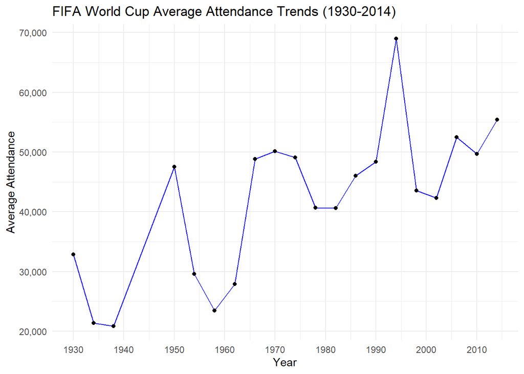

### 2. **Proportion of Countries that made it to the final (Pie Chart)**

**Which countries reached the final most often ?**

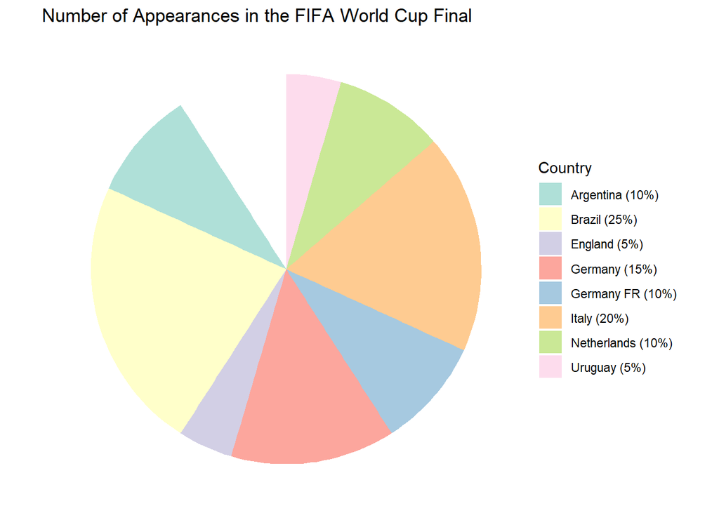

The pie chart clearly reveals that Brazil has the most appearances in the FIFA World Cup final, followed by Italy in second place, and Germany in third. Brazil, Italy, and Germany have often been top teams in the World Cup, showing their strong football skills over the years. Their regular appearances in the final show they are some of the best teams in the world.

### 3. **Top 10 Matchups by Average Attendance (Bar Chart)**

**Which matchups drew the largest crowds ?**

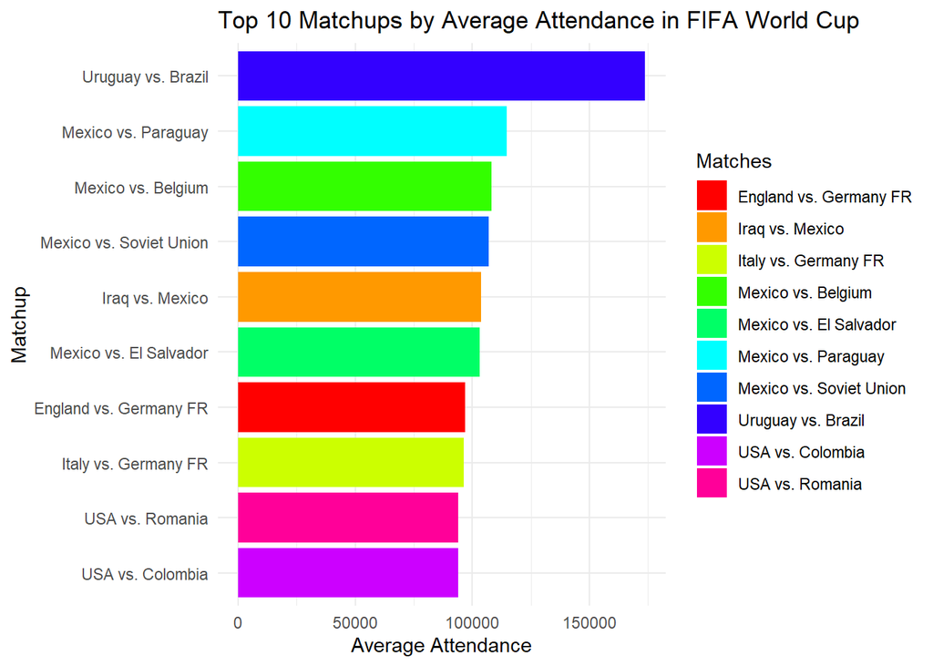

From this bar graph we can see that the match between Brazil and Uruguay was a very highly anticipated one and a lot of people chose to attend it in person. This tells us that some match ups between highly skilled teams can draw a large amount of crowds

### 4. **Goals Scored by Each Team in the 1958 World Cup (Tree Map)**

**Which teams scored the most goals in the 1958 World Cup, and how did they perform across stages ?**

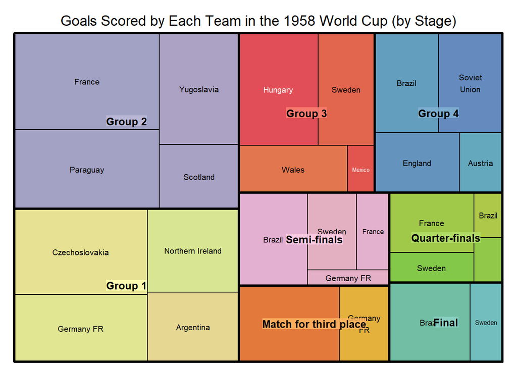

### 5. **Attendance by Host Country (Choropleth Map using `sf`)**

**How does the home team impact attendance ?**

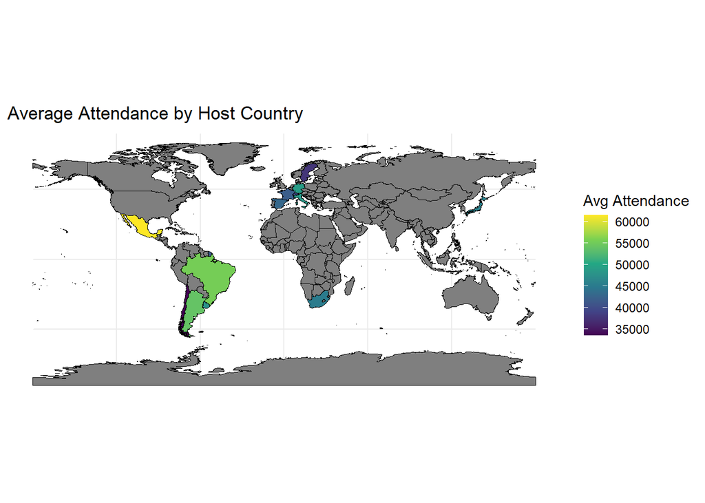

### 6. **Goal Distribution by Decade (Boxplot)**

**How do goal distributions vary by decade ?**

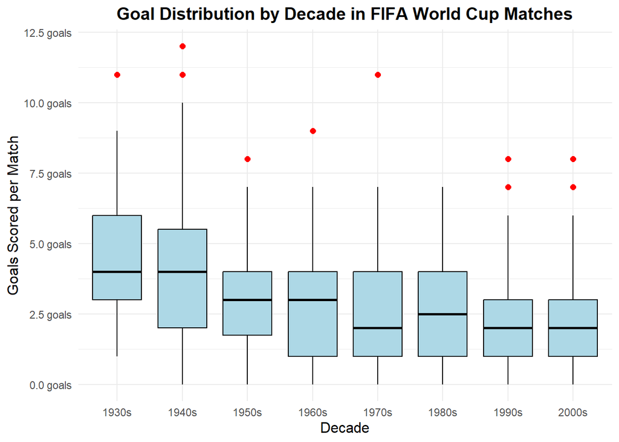

The boxplot shows us as that the average number of goals per match in FIFA World Cup games has decreased over the decades. Teams in the 1930s and 1940s had higher median goal counts and more extreme outliers, while more recent decades have lower median values and fewer high-scoring matches. This could be due to a variety of reasons such as strategies to play the game, as well as more skilled players

## References

1. https://www.kaggle.com/datasets/abecklas/fifa-world-cup
2. https://scales.r-lib.org/index.html
3. https://dplyr.tidyverse.org/
4. https://tidyr.tidyverse.org/
5. https://r-graph-gallery.com/treemap.html
6. https://ggplot2.tidyverse.org/reference/